# Demo of Riparian Vegetation Analysis

Elaina Passero

December 13, 2019

```r
knitr::opts_chunk$set(message = FALSE, warning = FALSE)
packages <- c("sp","raster","rgeos","rgdal","sf","spatstat","tidyverse","rasterVis",
              "ggplot2","data.table","dplyr","stars",
              "lubridate","rlist","rayshader","xtable","pander")

# load the installed libraries in the packages list
lapply(packages, library, character.only=TRUE)
```

## Project Background

The Verde River Environmental Flow Decision Support System (DSS) is a multi-faceted tool for evaluating the impacts of alternative flow scenarios on riparian and instream habitat. The tool has been developed to determine the environmental flow needs of the Verde Wild and Scenic River corridor, but it is applicable to any river system with the required inputs. The following document contains a demonstration of the methods available for analysis of riparian vegetation. Analysis is based on the riparian vegetation flow response guilds framework Merritt et al. (2010).

## Overview

### Study Area - Upstream Beasley site

This reach is approximately 0.5 km long. It is confined by relatively high canyon walls on the downstream portion of the reach. The channel splits around an island in the center of the channel at low flows.

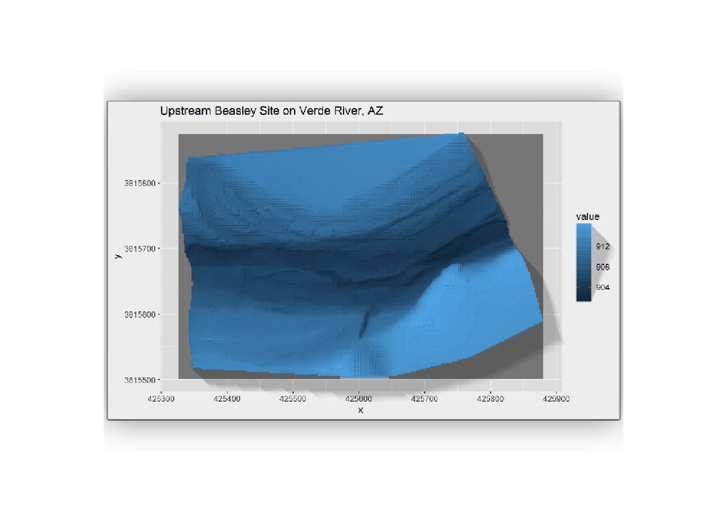

3D view of study reach

```r
study_area <- raster("inputs/BeasleyUS_0.25m_20191108.tif")
area_map <- gplot(study_area)+
  geom_tile(aes(fill=value))+
  ggtitle("Upstream Beasley Site on Verde River, AZ")

plot_gg(area_map,height = 5, width = 8, scale = 100, theta = 0, phi=85, zoom=.75)
render_snapshot(clear = TRUE)
```

### Vegetation Guilds

1. Drought tolerant shrubs
2. Tall trees

```r
veg_list <- c("drgt_tol_shrubs", "tall_trees")
```

### Flow Scenarios

The probability of occurrence of these flow response guilds will be related to daily exceedance probability of inundating discharges. Daily exceedance probability (EP) of inundating discharges will be calculated for three conditions:

1. Historic conditions
2. 25% reduction in all flows above the monthly median flows (red_above_med_25)
3. 10% reduction in all flows (red_all_q_10)

## Required Inputs

### Digital inundation map

The digital inundation map is a raster showing the discharge that inundates each cell in the study area. The cell size is 0.25 m by 0.25 m.

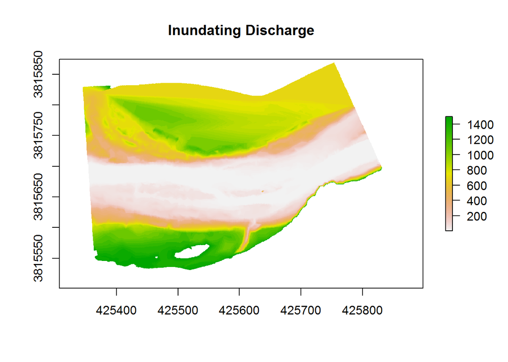

Digital inundation map for the study area.

```r
# load digital inundation map
wet_map <- raster("inputs/USBeasley1_DIM.tif")
plot(wet_map,main="Inundating Discharge")
```

### List of discharges with 2D modeling results

The 2D hydraulic model was run for 115 discharges. These results were used to make the digital inundation map.

```r
# load CSV of modeled discharges
modeled_q <- unlist(readr::read_csv("inputs/modeled_q_list.csv", col_names = FALSE))
```

### Time series of historic flow record and flow scenarios

These time series include daily discharge from 10-01-1988 to 9-31-2018. Discharge was calculated using upstream gage records and a rating curve.

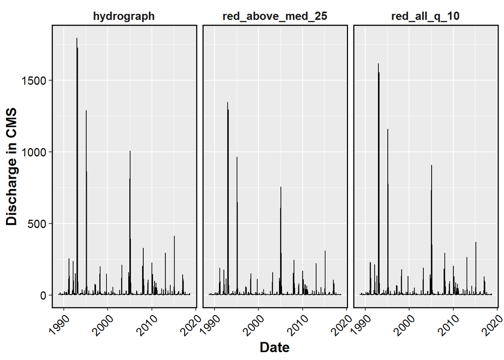

Hydrographs of historic conditions and the alternative scenarios.

```r
# load each flow scenario time series
scene_names <- list("hydrograph","red_above_med_25","red_all_q_10")

read_scenes <- function(name){
  file_name <- paste("inputs/USBeasley1_",name,".csv",sep="")
  hg <- readr::read_csv(file_name, col_names = TRUE)
  hg$date <- as.Date(hg$date, format="%m/%d/%Y")
  return(hg)
}

scene_list <- map(scene_names, read_scenes)
names(scene_list) <- scene_names
scene_plot_table <- bind_rows(scene_list, .id = "scene")

# plot hydrographs
ggplot(scene_plot_table,aes(x=date,y=discharge))+
  geom_line()+
  theme_gray()+
  theme(text=element_text(size=14,face = "bold",color = "black"),
      panel.border = element_rect(fill = NA,size=1),
      strip.background = element_rect(fill = NA),
      axis.text.x = element_text(colour = "black",face="plain",angle = 45,hjust=1),
      axis.text.y = element_text(colour = "black",face="plain"))+
  facet_wrap(~scene)+
  labs(x="Date",y="Discharge in CMS")
```

### Relationship between the flow response guilds and a flow component

Logistic regression equations relating EP and probability of occurrence were developed for guilds based on maps of vegetation produced at the site in 2016 and 2018.

```r
# display table of equations - due to the syntax of these equations, pandoc is the only one that works
logit_eqns <- readr::read_csv("inputs/USBeasley1_veg_pref.csv",col_names = TRUE)
var_names <- c("Eqn","B0","B1","B2")
logit_eqns_named <- add_column(logit_eqns, var_names, .before="tall_trees")
pandoc.table(logit_eqns_named, style='simple', split.tables = Inf)
```

```
##
##
##  var_names                   tall_trees                           drgt_tol_shrubs
## ----------- --------------------------------------------- -------------------------------
##     Eqn      exp(B0+B1*x+B2*x^2)/(1+exp(B0+B1*x+B2*x^2))   exp(B0+B1*x)/(1+exp(B0+B1*x))
##     B0                         -2.4661                                0.3163
##     B1                        466.6628                               -122.7203
##     B2                       -6710.9036                                 NA
```

## Calculate and Map Daily Exceedance Probability

EP is calculated for each discharge using the equation for Weibull plotting position shown below where m = rank, N = number of flows on record, and P = Exceedance Probability.

$$P = \frac{m}{N+1}$$

This value is based on frequency and rank and not on the magnitude of flows. EP values for a particular discharge may be different across different scenarios.

The modeled discharges are added into the data frame of discharges. Linear interpolation is used to find EP of the modeled discharges. If any modeled discharges are larger than the flows on record, they are added to the end of the flow scenario assuming one event per flow. Their weibull plotting position is calculated from their rank in relationship to the flows in the scenario. If any discharges in the scenario are less than the lowest modeled discharge, their EP is set to 1.

EP values for modeled discharges only are extracted. These were the discharges used to create the inundating discharge maps. The inundating discharge map is reclassified with the daily exceedance probability of inundation for each scenario.

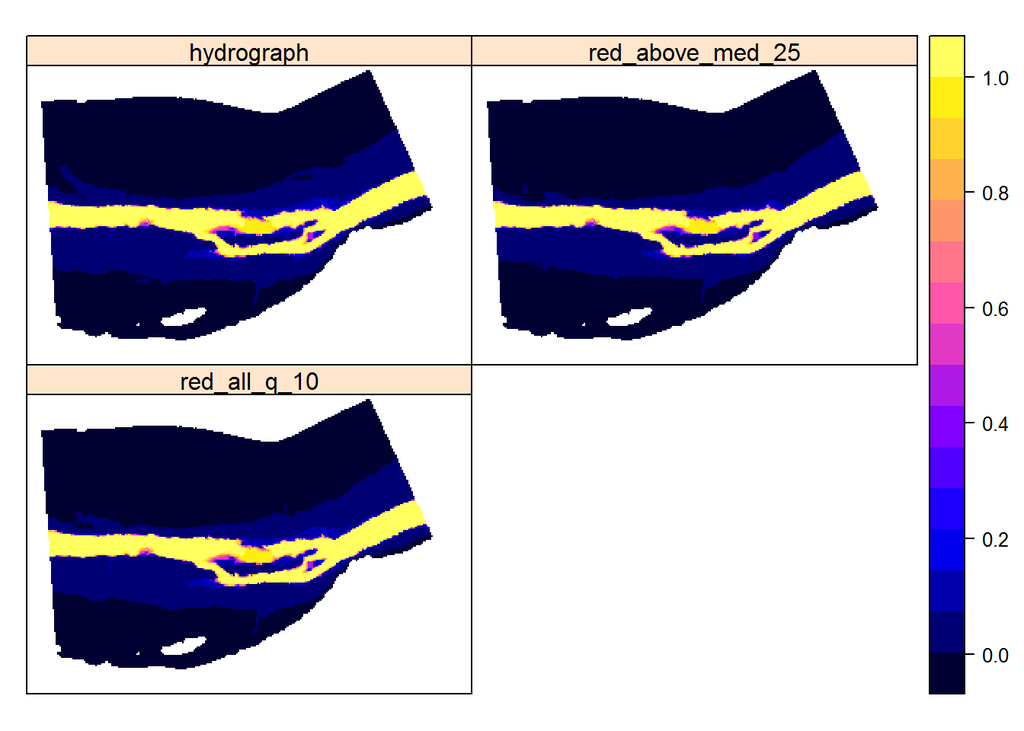

Maps of daily exceedence probability.

```r
# calculates daily EP for flows in flow scenario and any modeled discharges above scenario range
source("src/q.ep.weibull.R")
hydro_ep_list <- map(scene_list, q.ep.weibull, modeled_q)

# generates a map of daily EP
make.ep.maps <- function(hydro_ep){

  # get EP values for modeled discharges
  modeled_q_ep <- hydro_ep %>%
    filter(discharge %in% modeled_q) %>%
    distinct() %>%
    arrange(discharge)

  # build matrix for reclassification
  rcl_ep <- data.frame(from = modeled_q_ep$discharge,
               to = c(modeled_q_ep$discharge[-1],Inf),
               becomes = modeled_q_ep$EP) %>%
    as.matrix(.)

  # reclassify raster
  ep_map <- reclassify(wet_map, rcl_ep, right = FALSE)

  return(ep_map)
}

ep_map_list <- map(hydro_ep_list, make.ep.maps) # create EP maps

ep_stack <- stack(ep_map_list)
spplot(ep_stack)
```

## Make Maps of Probability of Occurrence

The logistic regression expressions are evaluated for each EP value in the flow scenarios. EP maps are reclassified using the outputs of those expressions to give the areal distribution of probability of occurrence of the vegetation guilds.

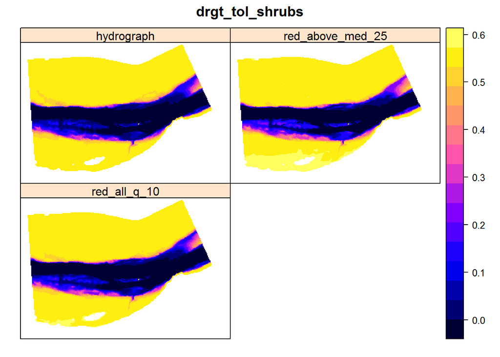

Maps of probability of occurrence of the two vegetation guilds by scenario.

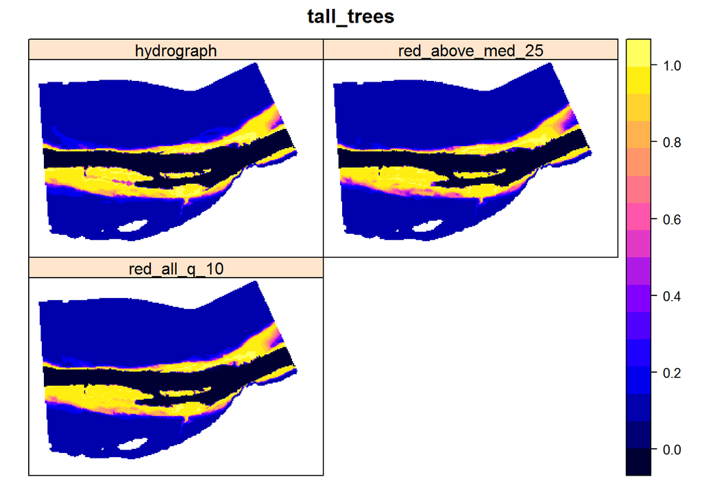

Maps of probability of occurrence of the two vegetation guilds by scenario.

```r
source("src/find.veg.logit.R") # extracts logistic regression equation for one guild
source("src/find.prob.occur.R") # calculates probability of occurrence of the guild by plugging EP into the equation
source("src/make.veg.maps.R") # reclassifies EP maps to probability of occurrence

make.prob.maps <- function(guild){
  one_veg_logit <- find.veg.logit(logit_eqns, guild)
  hydro_ep_prob_list <- map(hydro_ep_list, find.prob.occur, guild, one_veg_logit) # outputs discharges, EPs, and Prob of Veg
  prob_veg_map_stack <- stack(map2(hydro_ep_prob_list, ep_map_list, make.veg.maps, guild)) # creates stack of Prob of Veg maps
  return(prob_veg_map_stack)
}

prob_veg_map_list <- map(veg_list, make.prob.maps)
names(prob_veg_map_list) <- veg_list

plot.rast <- function(map_stack,title){
  spplot(map_stack,main=title)
}

map2(prob_veg_map_list,veg_list, plot.rast)
```

Notice that drought tolerant shrubs, which reside on upper terrace of the floodplain, have the highest probability of occurrence on the outer edges of the study area. Tall trees have the highest probability of occurrence overbank but near the channel.

### Distribution of probability of occurrence

These histograms were constructed directly from the rasters of probability of occurrence.

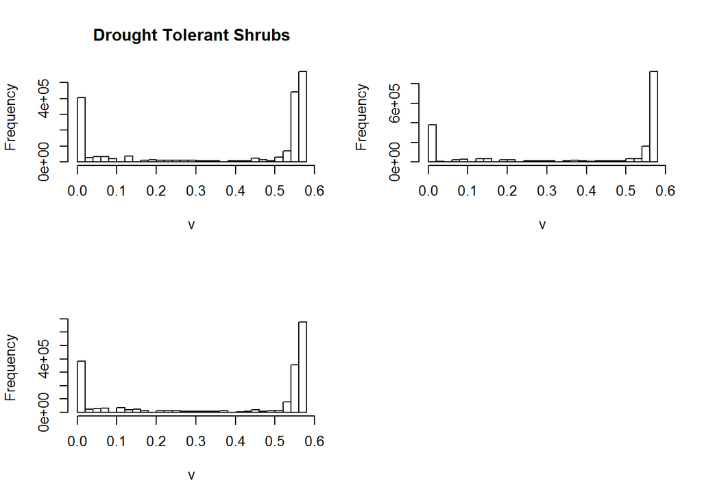

Distribution of probability of occurrence of drought tolerant shrubs in the study area. Plots are in the following order: Historic hydrograph, 25% reduction of flows above the monthly median, and 10% reduction of all flows.

```r
bx_plt_dts <- hist(prob_veg_map_list$drgt_tol_shrubs, main = "Drought Tolerant Shrubs")
```

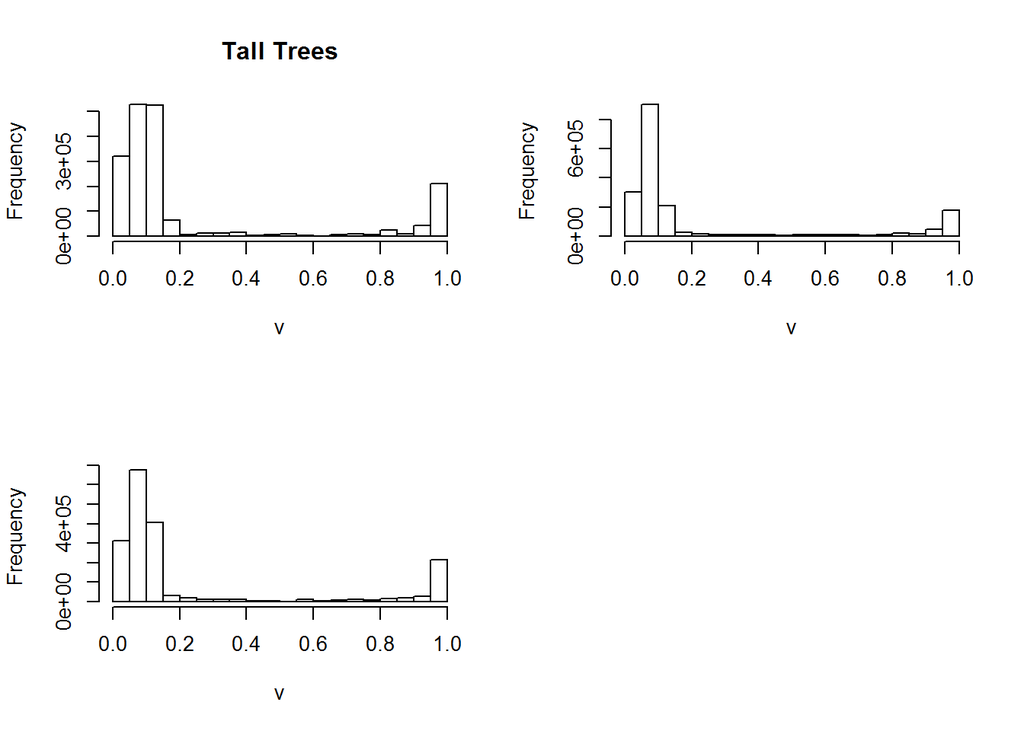

Distribution of probability of occurrence of tall trees in the study area. Plots are in the following order: Historic hydrograph, 25% reduction of flows above the monthly median, and 10% reduction of all flows.

```r
bx_plt_tt <- hist(prob_veg_map_list$tall_trees, main = "Tall Trees")
```

## Quantify Probability of Occurrence by Guild for each Scenario

Areas are reclassified as high (>0.7), moderate (0.6 to 0.7), and low probability of occurrence (<0.6) per guild.

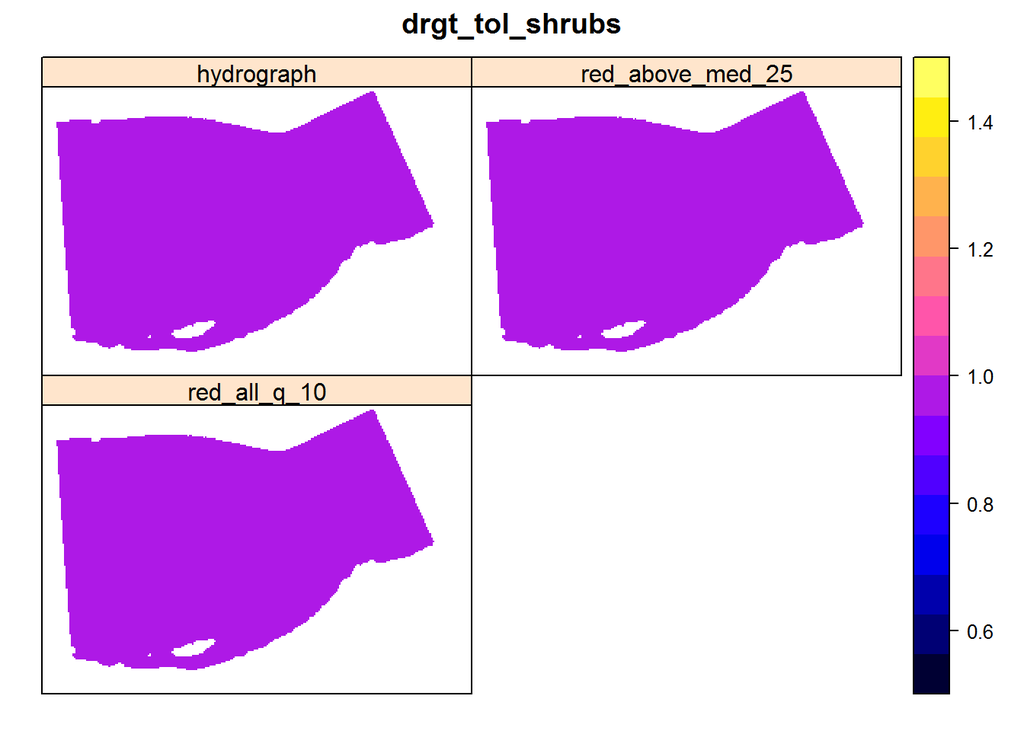

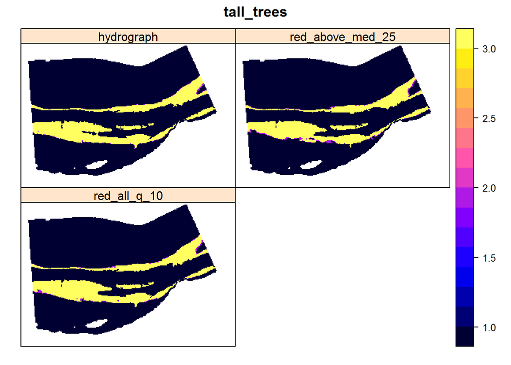

```r
# build matrix for reclassification
rcl_qual <- data.frame(from = c(-Inf,0.6,0.7),
                       to = c(0.6,0.7,Inf),
                       becomes = c(1,2,3)) %>%
  as.matrix(.)

# reclassify rasters
prob_quality_map_list <- map(prob_veg_map_list, reclassify, rcl_qual)
names(prob_quality_map_list) <- veg_list

map2(prob_quality_map_list,veg_list, plot.rast)
```

Neither of the scenarios is likely to result in encroachment from drought tolerant shrubs. However, there is a change in the distribution of the probability of tall trees.

### Total area by probability of occurrence

The total area of high, moderate, and low probability of occurrence per guild are calculated for each guild. Areas are in square meters.

```r
sum_area <- function(map_stack){ # per guild builds data frame of area in each quality for all scenarios
  map_list <- unstack(map_stack)

  sort_quality <- function(one_map){ # per scenario calculates area in each quality
    areas <- list()
    high <- one_map
    high[high != 3] <- NA
    areas$high_area <- cellStats(high,stat="sum",na.rm = TRUE)/3
    mod <- one_map
    mod[mod != 2] <- NA
    areas$mod_area <- cellStats(mod,stat="sum",na.rm = TRUE)/2
    low <- one_map
    low[low != 1] <- NA
    areas$low_area <- cellStats(low,stat="sum",na.rm = TRUE)
    areas_df <- bind_rows(areas)
    return(areas_df)
  }

  areas_df_list <- map(map_list,sort_quality)
  names(areas_df_list) <- scene_names
  all_scene_area_df <- bind_rows(areas_df_list,.id = "scene")
  return(all_scene_area_df)
}


all_guild_areas <- map(prob_quality_map_list,sum_area) # list of data frames of area by quality category

map(all_guild_areas, pandoc.table, style='simple')
```

```
##
##
##       scene         high_area   mod_area   low_area
## ------------------ ----------- ---------- ----------
##     hydrograph          0          0       1815041
##  red_above_med_25       0          0       1815041
##    red_all_q_10         0          0       1815041
##
##
##
##       scene         high_area   mod_area   low_area
## ------------------ ----------- ---------- ----------
##     hydrograph       301697       6987     1506357
##  red_above_med_25    278070      17713     1519258
##    red_all_q_10      298205      12932     1503904
```

For tall trees, the scenario reducing 10% of all flows maintains more areas with a high probability of occurrence than the alternative scenario. The 10% reduction scenario had an increase in moderate probability area and a decrease in the low probability area which could signal the potential for encroachment of tall trees. In this situation it is important to examine the maps of probability of occurrence.

## Compare the Results of the Scenarios to the Historic Conditions

### Areal distribution of higher probability areas

Since the drought tolerant shrubs had no areas of moderate or high probability of occurrence, the areal distribution of the higher probability areas does not need to be examined.

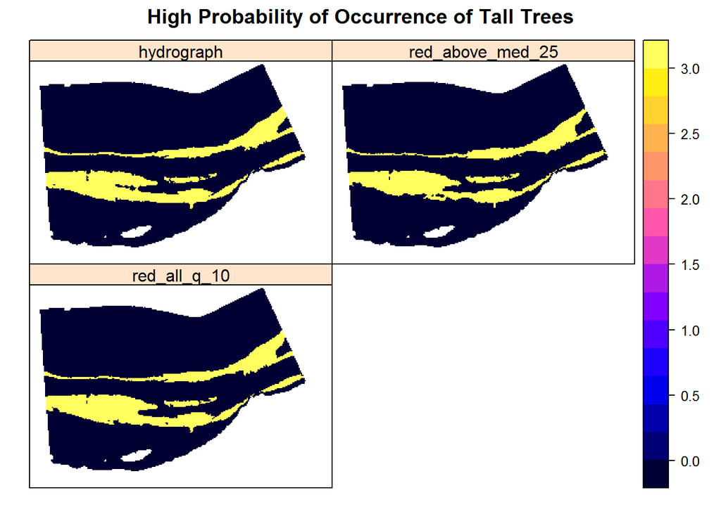

Maps of distribution of high probability areas for tall trees only.

```r
pq_map_tt_list <- unstack(prob_quality_map_list$tall_trees) # stack of tall trees

 higher_quality <- function(one_map){ # per scenario selects higher probability areas
    one_map[one_map != 3] <- 0
    return(one_map)
 }

 higher_prob_tt <- stack(map(pq_map_tt_list, higher_quality)) # create stack of high probability areas
 names(higher_prob_tt) <- scene_names

 spplot(higher_prob_tt,main = "High Probability of Occurrence of Tall Trees")
```

### Areal distribution of change in high probability areas for tall trees

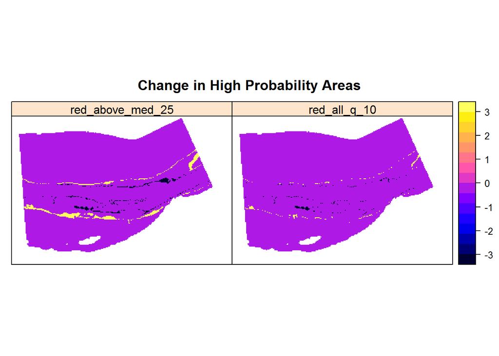

```r
base_map_tt <- higher_prob_tt$hydrograph
other_maps_tt <- higher_prob_tt[[2:3]]
map_chg <- function(one_map){
  chg_map <- base_map_tt-one_map
}

diff_map_brick <- base_map_tt - other_maps_tt
names(diff_map_brick) <- scene_names[2:3]
spplot(diff_map_brick, main = "Change in High Probability Areas")
```

### Change in total high probability area

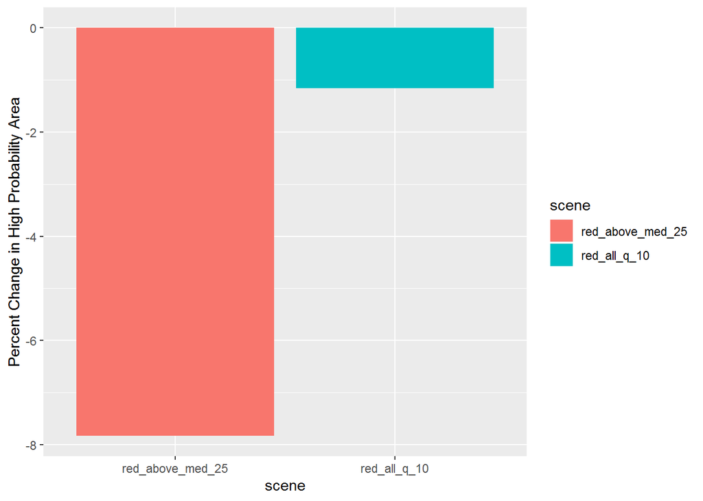

Barplot percent change in high probability of occurrence area by scenario.

```r
tt_baseline <- all_guild_areas$tall_trees %>% # historic total area of high probability
  filter(scene == "hydrograph") %>%
  select(high_area)

tt_alt_scenes <- all_guild_areas$tall_trees %>%
  select(scene,high_area) %>%
  filter(scene != "hydrograph") %>%
  mutate(per_chg = (high_area-tt_baseline$high_area)/tt_baseline$high_area*100) # calculate percent change from historic

ggplot(tt_alt_scenes,aes(x=scene, y=per_chg, fill=scene))+
  geom_bar(position = "dodge",stat = "identity")+
  labs(y = "Percent Change in High Probability Area")
```

The 25% reduction scenario leads to more change in high probability area than the 10% reduction scenario in both quantity and distribution. The maps of change show that habitat is being both lost and gained in greater quantities than in the 10% reduction scenario. Overall, the 25% reduction scenario had almost 8% loss in high probability areas compared to just over 1% loss for the 10% reduction scenario. However, changing the spatial distribution of where a guild resides, even if the total area remains the same, can have negative consequences for the ecosystem. It is important to include spatial representations of change in addition to summarizing those changes graphically.

## Incorporating Vegetation Results into the DSS

Characteristics of scenarios that can be evaluated from these results include:

1. Potential for vegetation encroachment.
2. Maintenance of high value vegetation or limitation low value vegetation like invasives.
3. Changes in the spatial distribution of vegetation guilds.
4. Net loss of high probability areas.

Evaluating change in the vegetation guilds in the study area is only one component of the DSS. These results should be combined with results from instream habitat for an understanding of the impacts on the ecosystem as a whole. In some situations it may also be appropriate to try to adjust flow scenarios to better serve riparian and instream habitat.

## References

Merritt, David M, Michael L Scott, N LeROY POFF, Gregor T Auble, and David A Lytle. 2010. “Theory, Methods and Tools for Determining Environmental Flows for Riparian Vegetation: Riparian Vegetation-Flow Response Guilds: Riparian Vegetation-Hydrologic Models.” *Freshw. Biol.* 55 (1): 206–25.